# Simple Linear Regression

Part 3: Examples using R

Ranadeep Daw

2024-10-03

# Instructions

1. Your HW3 has similar questions.
2. This is an exercise as well as contains new learning materials.
3. In statistical modeling, it is a common practice to receive data file and descriptions separately. I have provided guidance on how to interpret the data descriptions, often referred to as the metadata file.

# First question, based on data hosted on an external website.

### Let’s again go back to the pulse rate data that we used previously. The data was supplied by Dr Richard J. Wilson, Department of Mathematics, University of Queensland. The following is the link for the data and the metadata: [see here](http://www.statsci.org/data/oz/ms212.html). Read the description and understand which variable means what.

### When you try to practice at home, copy and run the following two lines first. This creates a dataframe called $\texttt{pulse_data}$ that has the data from the above link.

```r
pulse_data = read.table(url("http://www.statsci.org/data/oz/ms212.txt"), header = TRUE)
pulse_data = pulse_data[complete.cases(pulse_data), ]
```

## (Question 1): Covariance and Correlation

### A. We are going to build a regression model today using the pulse measurement before the experiment as the **independent variable or covariate** and the pulse measurement after the experiment as the **dependent variable or response**. From the metadata, can you guess what columns I need to use here? Also, following usual class notations, which one is $x$, which one is $y$ in my regression model?

**Answer:**

- From the description file, the variable *pulse measurement before the experiment* is in the column **Pulse1**. *Pulse measurement after the experiment* is in the column **Pulse2**.
- The independent variable ($x$) is: Pulse1.
- The dependent variable ($y$) is: Pulse2.

### B. Draw a scatterplot between the above two variables (i.e., pulse measurements before and after excercize). From the scatterplot, what kind of relationship do you guess here between the variables?

**Answer:**

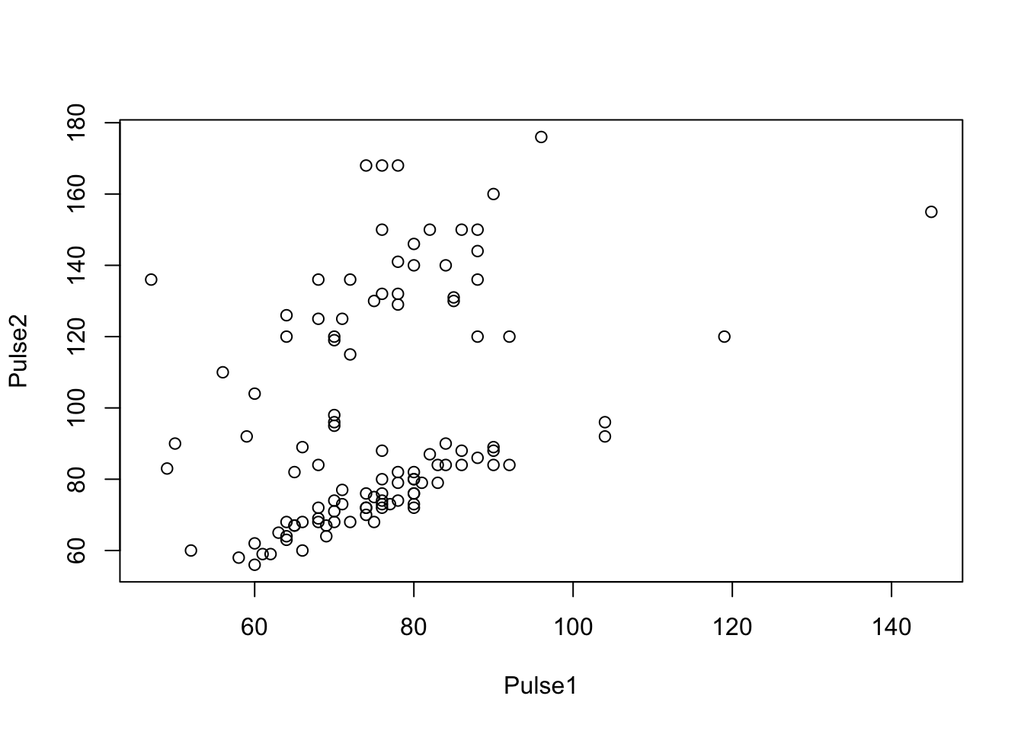

```r
Pulse1 = pulse_data$Pulse1
Pulse2 = pulse_data$Pulse2

plot(Pulse1, Pulse2)
```

It seems that there is a weak increasing relationship, i.e., $y$ is increasing with $x$ increasing.

### C. What is the covariance and correlation between the two variables? What kind of relationship do you guess here between the variables?

**Answer:**

```r
cov(Pulse1, Pulse2) # This is Covariance
```

```
## [1] 151.742
```

```r
cor(Pulse1, Pulse2) # This is Correlation
```

```
## [1] 0.3614805
```

Both covariance and correlation suggest a positive/increasing trend. However, the correlation value also suggests that the relationship is weak.

### D. Using the same two variables, can you demonstrate that the correlation between $\mathbf{x}$ and $\mathbf{y}$ is the same as the correlation between correlation between $\mathbf{y}$ and $\mathbf{x}$ $\big($i.e., cor($\mathbf{y, x}$) = cor($\mathbf{x, y}$) $\big)$?

**Answer:**

```r
# Just swapping the two variables. Check that this number is the same as the correlation before.
cor(Pulse2, Pulse1)
```

```
## [1] 0.3614805
```

### E. What is the Spearman’s rank correlation coefficient between the two variables?

**Answer:**

```r
# Same code as correlation, but you need to add method = "spearman"
cor(Pulse1, Pulse2, method = "spearman")
```

```
## [1] 0.4572993
```

## (Question 2): Regression Model

### A. Build the above simple linear regression model in $\texttt{R}$. Provide the estimated regression equation.

**Answer:**

```r
# Remember, the code is <model_name> = lm( <y_variable> ~ <x_variable>, data  = <data_name>)
model = lm(Pulse2   ~ Pulse1, data = pulse_data )
model
```

```
##
## Call:
## lm(formula = Pulse2 ~ Pulse1, data = pulse_data)
##
## Coefficients:
## (Intercept)       Pulse1
##     31.8476       0.8581
```

So, my regression equation is: $\widehat{y} = 31.85 + 0.86 x$.

### B. What is the interpretation of your estimated $\widehat{\beta}_0$?

**Answer:** $\widehat{\beta}_0 = 31.85$ is the estimated value of Pulse2 (or $y$) when Pulse1 (or $x$) is equal to 0.

### C. What is the interpretation of your estimated $\widehat{\beta}_1$?

**Answer:** $\widehat{\beta}_1 = 0.86$ is the estimated change in Pulse2 (or $y$) when Pulse1 (or $x$) changes by 1 unit.

### D. Find and interpret $R^2$, also denoted by the coefficient of determination.

**Answer:**

For this question, you will need the summary of the model. So let’s print it first.

```r
summary(model)
```

```
##
## Call:
## lm(formula = Pulse2 ~ Pulse1, data = pulse_data)
##
## Residuals:
##    Min     1Q Median     3Q    Max
## -29.09 -23.07 -17.92  28.08  72.65
##
## Coefficients:
##             Estimate Std. Error t value Pr(>|t|)
## (Intercept)  31.8476    16.4415   1.937 0.055379 .
## Pulse1        0.8581     0.2140   4.010 0.000113 ***
## ---
## Signif. codes:  0 '***' 0.001 '**' 0.01 '*' 0.05 '.' 0.1 ' ' 1
##
## Residual standard error: 29.57 on 107 degrees of freedom
## Multiple R-squared:  0.1307, Adjusted R-squared:  0.1225
## F-statistic: 16.08 on 1 and 107 DF,  p-value: 0.0001125
```

I have hosted this output [here](https://raw.githubusercontent.com/dawranadeep/24FA_git/refs/heads/main/Practice_qns/img/pulse_summary.png). Keep it open in a separate tab for this exercise.

Now you have to remember that the value of $R^2$ is written beside $\texttt{## Multiple R-squared:}.$ So, from the output table, $R^2 = 0.1307$.

Also, $R^2$ is the percentage of the explained variability of $y$ by the model. So, here, only $13\%$ variability in Pulse2 ($y$) is being explained by the model.

### E. Verify that $R^2$ is square of the corrleation coefficient between the two variables.

**Answer:**

```r
# Take a square of the correlation coefficient you calculated in 1C
# See that this number is same as the R^2
cor(Pulse1, Pulse2)^2
```

```
## [1] 0.1306681
```

### F. Plot the regression line on top of the scatter plot of the data.

**Answer:**

For this, first do the scatterplot. Then, use the command $\texttt{abline(<model_name>}$. You can give it a color by adding $\texttt{col=...}$.

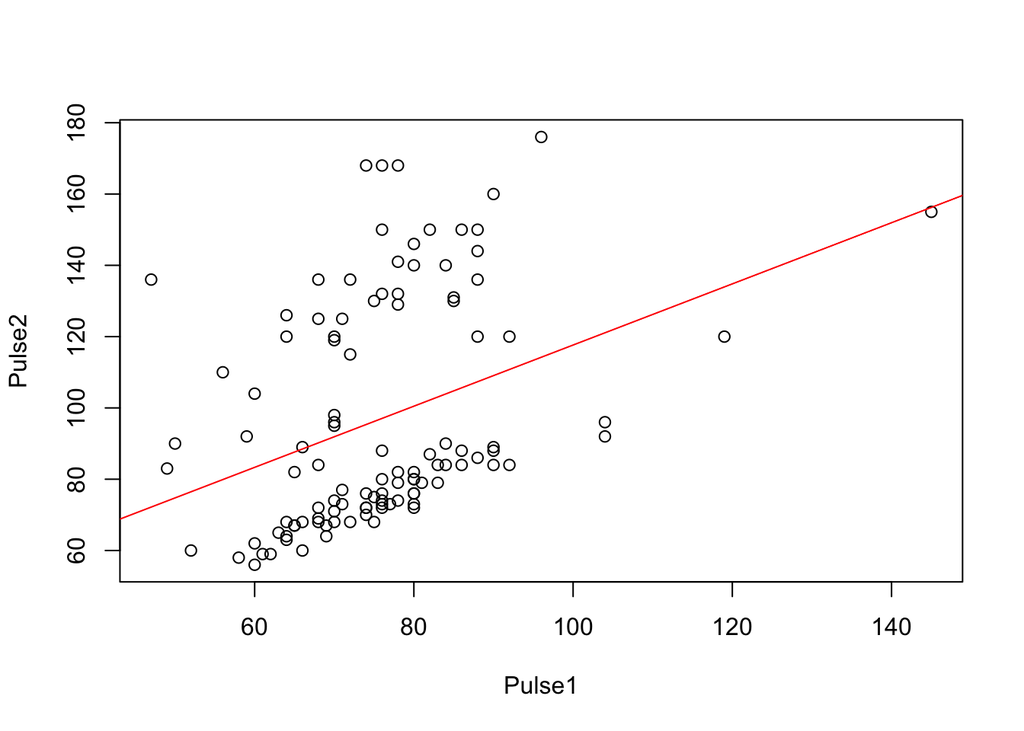

```r
plot(Pulse1, Pulse2) #Scatterplot from 1B
abline(model, col="red") # Plotting the model
```

## (Question 3) Prediction and Residuals

### A. Use the model to predict the second pulse rate when the first pulse rate is 70.

**Answer:**

Careful! This one is tricky. The usual syntax of the code is:

```r
predict(<model_name>, newdata = data.frame(<x_variable> = <value>))
```

Here the $\texttt{<model_name>}$ is $\texttt{model}$; $\texttt{<x_variable>}$ is $\texttt{Pulse1}$; $\texttt{<value>}$ is $\texttt{70}$. Let’s complete the code now.

```r
# Code
predict(model, newdata = data.frame(Pulse1 = 70) )
```

```
##        1
## 91.91703
```

### B. Use the model to predict the second pulse rate when the first pulse rate is 45.

Following the same syntax as before.

```r
predict(model, newdata = data.frame(Pulse1 = 45))
```

```
##        1
## 70.46366
```

### C. What is the estimated error standard deviation? What is the estimated error variance?

**Answer:**

Again, go to the model output (link [here](https://raw.githubusercontent.com/dawranadeep/24FA_git/refs/heads/main/Practice_qns/img/pulse_summary.png)). Keep this open.

For $\hat{\sigma}$, you should see the line beside $\texttt{## Residual standard error:}$. So, $\hat{\sigma} = 29.57$.

For error variance $\hat{\sigma}^2$, you have to manually square the above number.

```r
29.57^2 #Error variance
```

```
## [1] 874.3849
```

So, $\hat{\sigma}^2 = 874.38$.

### D. Plot the residuals from the model and plot them against the fitted values. Is there any pattern?

Something similar is going to be needed for your HW3 Question 6. Note: plot(model) usually gives you 4 plots. For the residual vs fitted plot, you have to use the first one.

**Answer:**

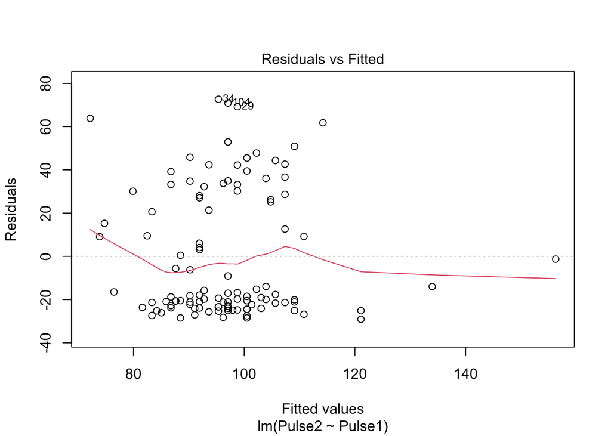

```r
plot(model, which = 1)
```

## (Question 4): Hypothesis testing

### A. Test whether the slope ($\beta_1$) of the regression line is significantly different from zero. Use a significance level of 0.05. State the null and alternative hypotheses, and report the p-value and your conclusion.

**Answer:**

Anytime you do the test for coefficients, you go to the summary table and look at the Coefficient table from there. I mean that the following part:

```
##             Estimate Std. Error t value  Pr(>|t|)
## (Intercept) 31.84760   16.44147  1.9370 0.0553786 .
## Pulse1       0.85813    0.21398  4.0104 0.0001125 ***
## ---
## Signif. codes:  0 '***' 0.001 '**' 0.01 '*' 0.05 '.' 0.1 ' ' 1
```

- Column 1 ($\texttt{Estimate}$) is the estimated coefficients or $\widehat{\beta}_0, \widehat{\beta}_1$.
- Column 2 ($\texttt{Std. Error}$) is their standard deviations.
- Column 3 ($\texttt{t value}$) is the T statistic.
- Column 4 ($\texttt{Pr(>|t|)}$) is the p-value.

Now, from the question, I am supposed to test $H_0$: $\beta_1 = 0$ vs $H_A$: $\beta_1 \neq 0$. This means that I have to deal with the row corresponding to $\texttt{Pulse1}$ here.

Here, p-value = 0.0001 < $\alpha$ ( =0.05). So, we have enough evidence to reject the $H_0$.

### B. In the above test, what is the value of the test statistic? Show that the test statistic is equal to $\frac{\widehat{\beta}_1 \text{ - } 0}{\text{sd}(\widehat{\beta}_1)}$?

**Answer:**

Again, the same coefficient table. The test statistic for $\widehat{\beta}_1$ is $4.0104$. Let’s now check if it is $\texttt{Estimate/Std. Error}$ or not.

```r
# Do Estimate/Std. Error for Pulse1
0.85813/0.21398
```

```
## [1] 4.010328
```

So, we get the same number.

### C. Find the 95% confidence interval for the slope $\beta_1$.

The syntax for confidence interval is:

```r
confint(<model_name>, level = <level_value>)
```

Let’s do it now.

```r
confint(model, level = 0.95)
```

```
##                  2.5 %    97.5 %
## (Intercept) -0.7457000 64.440900
## Pulse1       0.4339459  1.282324
```

So, the 95% CI for $\beta_1$ is: (0.43, 1.28).

So, if I ask you test $H_0$: $\beta_1 = 0$ vs $H_A: \beta_1 \neq 0$ at $\alpha = 0.05$, just check if the corresponding confidence interval contains $0$ or not. Here, 0 is not inside; hence reject $H_0$.

So, if I ask you test $H_0$: $\beta_1 = 1$ vs $H_A: \beta_1 \neq 1$ at $\alpha = 0.05$, just check if the corresponding confidence interval contains $1$ or not. Here, 1 isinside the CI; hence fail to reject $H_0$.

### D. Test whether the model makes any sense or not. Use a significance level of 0.05. State the null and alternative hypotheses, and report the p-value and your conclusion.

This is the model significance test. For the significance test, you will look at the last line of the summary output; everything after $\texttt{## F-statistic: ...}$.

The hypothesis test has the form: $H_0$: $\beta_1 = 0$ vs $H_A$: $\beta_1 \neq 0$.

p-value = 0.0001 < $\alpha (= 0.05)$. Reject $H_0$.

## (Question 5): Leverage and Influence

### A. Calculate the leverage score values from this regression model.

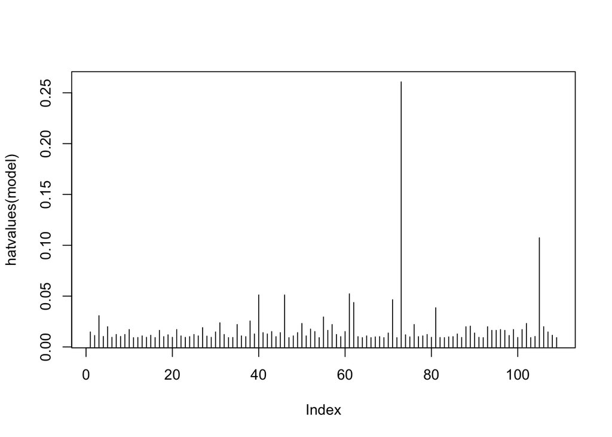

```r
plot(hatvalues(model), type = 'h')
```

### B. How would you identify influential points using Cook’s Distance?

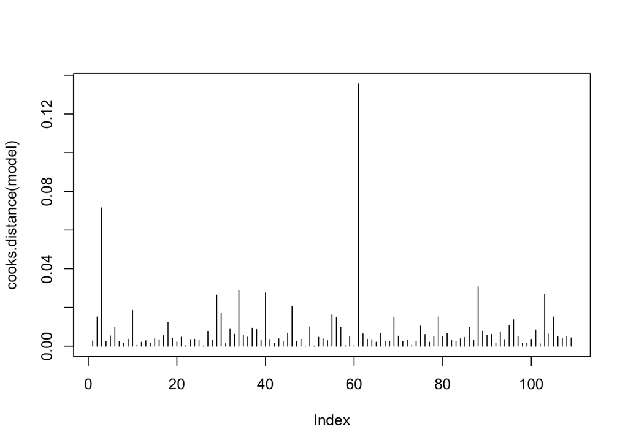

```r
plot(cooks.distance(model), type = 'h')
```

**Answer**:

# Second question, based on an internal data that comes with $\texttt{R}$ - the $\texttt{mtcars}$ data.

## (Question 6): Covariance and Correlation

### Load the $\texttt{mtcars}$ data. For internal $\texttt{R}$ datasets, see the metadata by typing $\texttt{?mtcars}$.

### A. We are going to build a regression model today using the Displacement (cu.in.) as the **independent variable or covariate** and mpg as the **dependent variable or response**. From the metadata, can you guess what columns I need to use here? Also, following usual class notations, which one is $x$, which one is $y$ in my regression model?

**Answer:**

First, load the data and read the description/ metadata.

```r
data("mtcars")
?mtcars
```

Note, in this document, nothing will show when you do $\texttt{?mtcars}$. You have to copy paste the above two lines in $\texttt{R}$ console to see the output. Read the description from there.

- Here, the columns **disp** is the independent variable.
- **mpg** is the dependent variable.

### B. Draw a scatterplot between the above two variables. From the scatterplot, what kind of relationship do you guess here between the variables?

**Answer:**

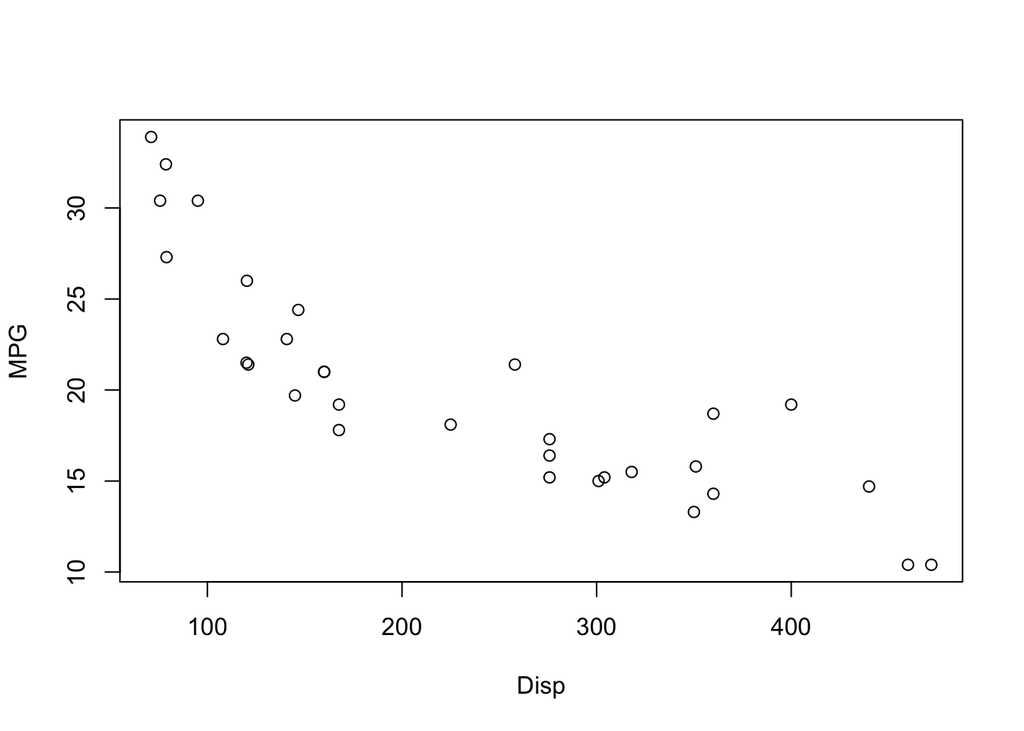

```r
data("mtcars")
Disp = mtcars$disp
MPG  = mtcars$mpg

plot(Disp, MPG)
```

A strong negative pattern is visible in the plot.

### C. What is the covariance and correlation between the two variables? What kind of relationship do you guess here between the variables?

**Answer:**

```r
cov(Disp, MPG)
```

```
## [1] -633.0972
```

```r
cor(Disp, MPG)
```

```
## [1] -0.8475514
```

Both covariance and correlation suggest a negative trend. However, the correlation value also suggests that the relationship is very strong.

### D. Using the same two variables, can you demonstrate that the correlation between $\mathbf{x}$ and $\mathbf{y}$ is the same as the correlation between correlation between $\mathbf{y}$ and $\mathbf{x}$ $\big($i.e., cor($\mathbf{y, x}$) = cor($\mathbf{x, y}$) $\big)$?

**Answer:**

```r
cor(MPG, Disp)
```

```
## [1] -0.8475514
```

### E. What is the Spearman’s rank correlation coefficient between the two variables?

**Answer:**

```r
cor(Disp, MPG, method = "spearman")
```

```
## [1] -0.9088824
```

## (Question 7): Regression Model

### A. Build the above simple linear regression model in $\texttt{R}$. Provide the estimated regression equation.

**Answer:**

```r
model2 = lm(mpg ~ disp, data = mtcars)
model2
```

```
##
## Call:
## lm(formula = mpg ~ disp, data = mtcars)
##
## Coefficients:
## (Intercept)         disp
##    29.59985     -0.04122
```

### B. What is the interpretation of your estimated $\widehat{\beta}_0$?

**Answer:** $\widehat{\beta}_0 = 29.60$ is the estimated value of mpg (or $y$) when disp (or $x$) is equal to 0.

### C. What is the interpretation of your estimated $\widehat{\beta}_1$?

**Answer:** $\widehat{\beta}_1 = -0.04$ is the estimated change in mpg (or $y$) when disp (or $x$) changes by 1 unit.

### D. Find and interpret $R^2$, also denoted by the coefficient of determination.

**Answer:**

Again, you need the summary table. Following table is hosted [here](https://raw.githubusercontent.com/dawranadeep/24FA_git/refs/heads/main/Practice_qns/img/mtcars_summary.png). Keep it open for various parts of this problem.

```r
summary(model2)
```

```
##
## Call:
## lm(formula = mpg ~ disp, data = mtcars)
##
## Residuals:
##     Min      1Q  Median      3Q     Max
## -4.8922 -2.2022 -0.9631  1.6272  7.2305
##
## Coefficients:
##              Estimate Std. Error t value Pr(>|t|)
## (Intercept) 29.599855   1.229720  24.070  < 2e-16 ***
## disp        -0.041215   0.004712  -8.747 9.38e-10 ***
## ---
## Signif. codes:  0 '***' 0.001 '**' 0.01 '*' 0.05 '.' 0.1 ' ' 1
##
## Residual standard error: 3.251 on 30 degrees of freedom
## Multiple R-squared:  0.7183, Adjusted R-squared:  0.709
## F-statistic: 76.51 on 1 and 30 DF,  p-value: 9.38e-10
```

$R^2 = 0.72$. So, 72% variability of mpg is being explained by the model.

### E. Verify that $R^2$ is square of the corrleation coefficient between the two variables.

**Answer:**

```r
cor(Disp, MPG)^2
```

```
## [1] 0.7183433
```

### F. Plot the regression line on top of the scatter plot of the data.

**Answer:**

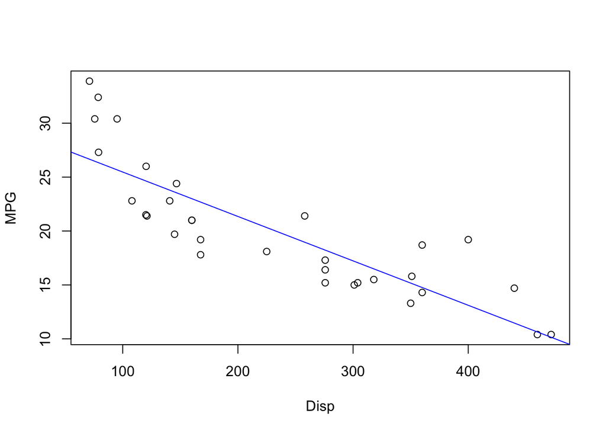

```r
plot(Disp, MPG) #scatterplot
abline(model2, col = "blue")
```

## (Question 8) Prediction and Residuals

### A. Use the model to predict the mpg when the displacement is 230.

**Answer:**

Again, the usual syntax of the code is:

```r
predict(<model_name>, newdata = data.frame(<x_variable> = <value>))
```

So, let’s fill in the options here.

```r
predict(model2, newdata = data.frame(disp = 230) )
```

```
##        1
## 20.12038
```

### B. Use the model to predict the mpg when the displacement is 300.

**Answer:**

```r
predict(model2, newdata = data.frame(disp = 300))
```

```
##        1
## 17.23532
```

### C. What is the estimated error standard deviation? What is the estimated error variance?

**Answer:** Again, keep the summary table open (link [here](https://raw.githubusercontent.com/dawranadeep/24FA_git/refs/heads/main/Practice_qns/img/mtcars_summary.png)). See the $\hat{\sigma}$ beside $\texttt{## Residual standard error:...}$ and square it for $\hat{\sigma}^2$.

```r
3.251^2
```

```
## [1] 10.569
```

$\hat{\sigma} = 3.251; \hat{\sigma}^2 = 10.57$.

### D. Plot the residuals from the model and plot them against the fitted values. Is there any pattern?

**Answer:**

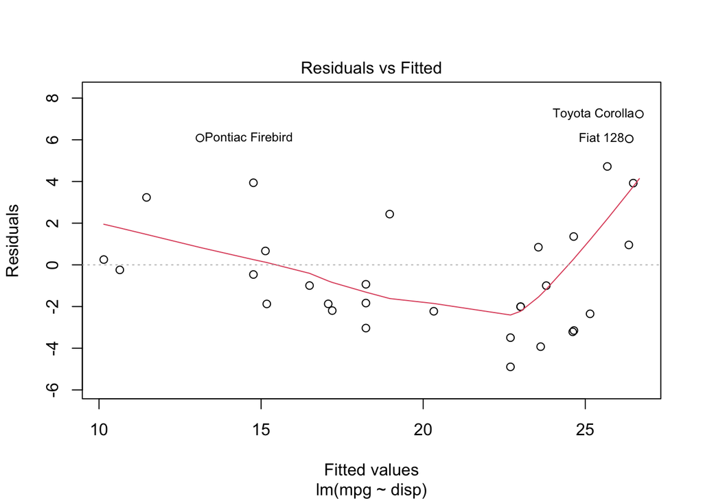

```r
plot(model2, which = 1)
```

## (Question 9): Hypothesis testing

### A. Test whether the slope ($\beta_1$) of the regression line is significantly different from zero. Use a significance level of 0.05. State the null and alternative hypotheses, and report the p-value and your conclusion.

**Answer:**

$H_0$: $\beta_1 = 0$ vs $H_A$: $\beta_1 \neq 0$.

Let’s look at the coefficients table, i.e.,

```
##               Estimate Std. Error t value  Pr(>|t|)
## (Intercept) 29.5998548  1.2297195 24.0704 < 2.2e-16 ***
## disp        -0.0412151  0.0047118 -8.7472  9.38e-10 ***
## ---
## Signif. codes:  0 '***' 0.001 '**' 0.01 '*' 0.05 '.' 0.1 ' ' 1
```

p-value = 0. Reject $H_0$.

### B. In the above test, what is the value of the test statistic? Show that the test statistic is equal to $\frac{\widehat{\beta}_1 \text{ - } 0}{\text{sd}(\widehat{\beta}_1)}$?

**Answer:**

Test statistic = -8.747.

```r
-0.041215/0.004712
```

```
## [1] -8.746817
```

So, we get the same number.

### C. Find the 95% confidence interval for the slope $\beta_1$.

```r
confint(model2, level = 0.95)
```

```
##                   2.5 %      97.5 %
## (Intercept) 27.08843246 32.11127705
## disp        -0.05083797 -0.03159227
```

### D. Test whether the model makes any sense or not. Use a significance level of 0.05. State the null and alternative hypotheses, and report the p-value and your conclusion.

Test statistic = 76.51. p-value = 0. Hence, reject $H_0$ i.e., our model is significant.

## (Question 10): Leverage and Influence

### A. Calculate the leverage score values from this regression model.

**Answer**:

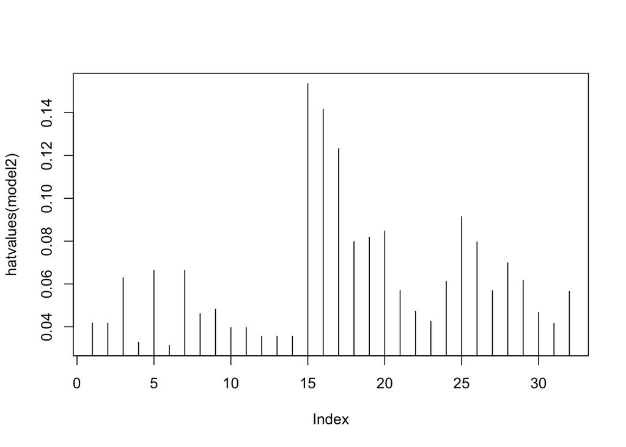

```r
plot(hatvalues(model2), type = 'h')
```

### B. How would you identify influential points using Cook’s Distance?

**Answer**:

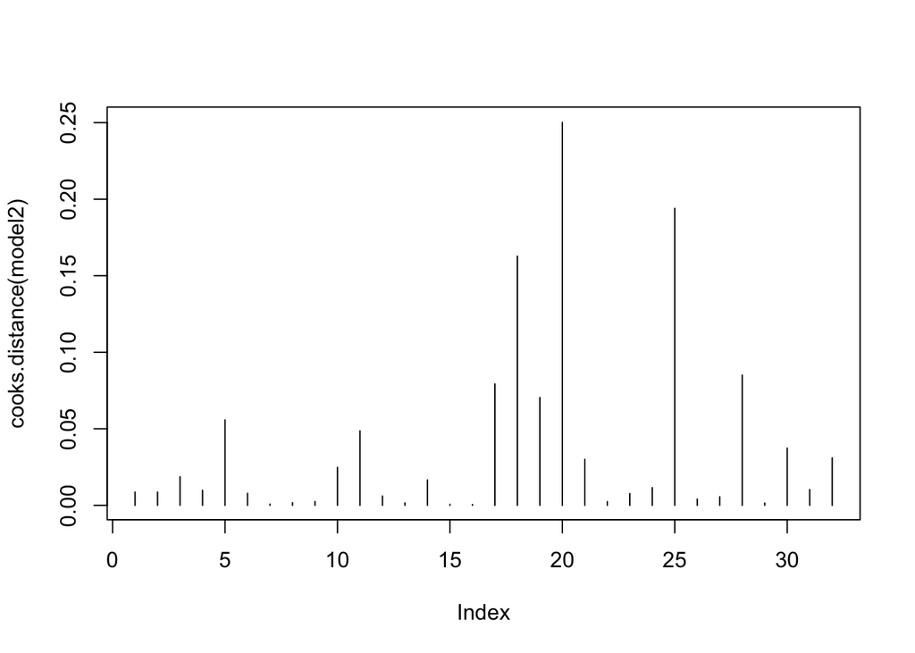

```r
plot(cooks.distance(model2), type = 'h')
```